# SyncVariability-MR3-QTM

## Variable Synchronisation MR3 -- QTM: Was wir wissen

**Problem**

Wenn myoMOTION zusammen mit QTM gestartet wird, kommt es zu einer variablen Synchronität der Daten. Folgende Daten wurden von Ursula übermittelt:

- MW: 243ms, SD: 42
- MIN: 170ms MAX: 295ms
- (Paramter zur Synchronisierung?)

Dabei scheint QTM immer später zu starten als MR3.

**QTM**

Delta_t von Drücken des Trigger Buttons bis zum ersten Kameraframe ist per default 20ms.

**MR3**

? da niemand dieses Setup bisher verwendet hat.

### 1 Vorgehensweise

Bei Velamed habe ich ein ähnliches Setup aufgebaut, um die Differenz in der Synchronisation verifizieren zu können und mögliche falsche Einstellungen auszuschließen.

t_delta = t_bodenMM - t_bodenQTM ergibt den Synchronisierungsunterschied/Zeitversatz beider Systeme.

**Setup**

- Messfrequenz: 100Hz (beide Systeme)
- 4 Qqus Kameras (gemischt 3+, 5+)
- Verwendeter myoMOTION Sensor: Becken
- Start von QTM und MR3 via Trigger Button (Trigger Signal wurde mit t-BNC Stück gesplittet)

```python
import pandas as pd
import glob
import numpy as np
import matplotlib.pyplot as plt
import seaborn
import re

folder = "C:\\Users\\b.ellinger\\Desktop\\task_Force\\02#_support_data\\#1018\\"
fIDs = {'mm': glob.glob(folder+'*.csv'),
        'qtm': glob.glob(folder+'*.tsv')
}

#mm = pd.read_csv(fIDs['mm'][2], delimiter=';', skiprows=4)
#qtm = pd.read_csv(fIDs['qtm'][2], delimiter='\t', skiprows=10)

fIDs
```

```
{'mm': ['C:\\Users\\b.ellinger\\Desktop\\task_Force\\02#_support_data\\#1018\\mm+qtm-0.csv',
  'C:\\Users\\b.ellinger\\Desktop\\task_Force\\02#_support_data\\#1018\\mm+qtm-1.csv',
  'C:\\Users\\b.ellinger\\Desktop\\task_Force\\02#_support_data\\#1018\\mm+qtm-2.csv',
  'C:\\Users\\b.ellinger\\Desktop\\task_Force\\02#_support_data\\#1018\\mm+qtm-3.csv',
  'C:\\Users\\b.ellinger\\Desktop\\task_Force\\02#_support_data\\#1018\\mm+qtm-4.csv',
  'C:\\Users\\b.ellinger\\Desktop\\task_Force\\02#_support_data\\#1018\\mm+qtm-5.csv',
  'C:\\Users\\b.ellinger\\Desktop\\task_Force\\02#_support_data\\#1018\\mm+qtm-6.csv',
  'C:\\Users\\b.ellinger\\Desktop\\task_Force\\02#_support_data\\#1018\\mm+qtm-7.csv',
  'C:\\Users\\b.ellinger\\Desktop\\task_Force\\02#_support_data\\#1018\\mm+qtm-8.csv',
  'C:\\Users\\b.ellinger\\Desktop\\task_Force\\02#_support_data\\#1018\\mm+qtm-9.csv'],
 'qtm': ['C:\\Users\\b.ellinger\\Desktop\\task_Force\\02#_support_data\\#1018\\mm+qtm0000.tsv',
  'C:\\Users\\b.ellinger\\Desktop\\task_Force\\02#_support_data\\#1018\\mm+qtm0001.tsv',
  'C:\\Users\\b.ellinger\\Desktop\\task_Force\\02#_support_data\\#1018\\mm+qtm0002.tsv',
  'C:\\Users\\b.ellinger\\Desktop\\task_Force\\02#_support_data\\#1018\\mm+qtm0003.tsv',
  'C:\\Users\\b.ellinger\\Desktop\\task_Force\\02#_support_data\\#1018\\mm+qtm0004.tsv',
  'C:\\Users\\b.ellinger\\Desktop\\task_Force\\02#_support_data\\#1018\\mm+qtm0005.tsv',
  'C:\\Users\\b.ellinger\\Desktop\\task_Force\\02#_support_data\\#1018\\mm+qtm0006.tsv',
  'C:\\Users\\b.ellinger\\Desktop\\task_Force\\02#_support_data\\#1018\\mm+qtm0007.tsv',
  'C:\\Users\\b.ellinger\\Desktop\\task_Force\\02#_support_data\\#1018\\mm+qtm0008.tsv',
  'C:\\Users\\b.ellinger\\Desktop\\task_Force\\02#_support_data\\#1018\\mm+qtm0009.tsv']}
```

Obige Dateien gehen in die Analyse ein. Die *.tsv-Dateien* sind Exports aus QTM, *.csv-Dateien* sind Exports aus MR3. Beide n=10.

### 2 Analyse der zeitlichen Parameter der Messungen

Als ersten Schritt analysieren wir die Anzahl an Frames pro Datei (d.h. Länge der Messung), welche nach Theorie eigentlich identisch sein müsste.

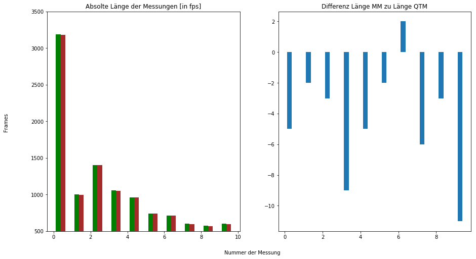

```python
length = [[],[],[]] # 0 = mm, 1 = qtm, 2 = delta_t
for a in range(10):
    mm = pd.read_csv(fIDs['mm'][a], delimiter=';', skiprows=4)
    qtm = pd.read_csv(fIDs['qtm'][a], delimiter='\t', skiprows=10)
    length[0].append(len(mm))
    length[1].append(len(qtm))
    length[2].append(len(mm) - len(qtm))

fig1 = plt.figure(figsize=(15,8))
ax1 = fig1.add_subplot(1,2,1)
ax2 = fig1.add_subplot(1,2,2)

bar_width = 0.25
bar_position = np.arange(10) + bar_width
ax1.bar(bar_position, length[1][:], bar_width, color='green', label='QTM')
ax1.bar(bar_position+0.25, length[0][:], bar_width, color='brown', label='myoMOTION')
ax1.set_ylim(500, 3500)
ax1.set_title("Absolte Länge der Messungen [in fps]")

ax2.bar(bar_position, length[2][:], bar_width)
ax2.set_title("Differenz Länge MM zu Länge QTM")

fig1.text(0.5, 0.05, 'Nummer der Messung', ha='center', va='center')
fig1.text(0.05, 0.5, 'Frames', ha='center', va='center', rotation='vertical')

plt.legend
plt.show()
```

In den MM-Dateien haben wir ein Triggersignal, dass die Länge der eigentlichen Messung beschreibt. Dahingehend können wir untersuchen, ob die Zeit von frame=0 bis Triggersignal immer gleich ist.

Das Bild unten zeigt den analysierten Zeitraum a) bis Messtart und b) von Messende.

[figure not shown]

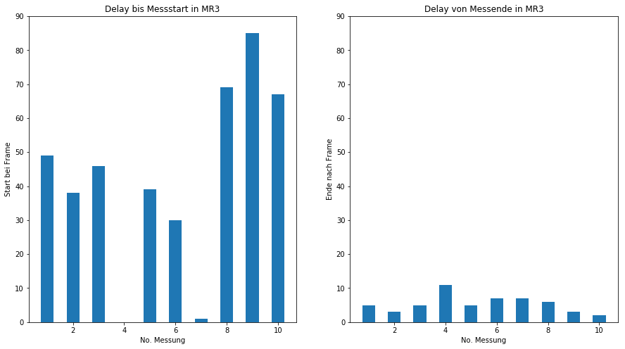

```python
sync_indeces1, sync_indeces2 = [], []
for file in fIDs['mm']:
    mm = pd.read_csv(file, delimiter=';', skiprows=4)
    sync = mm['Noraxon MyoMotion.Sync,An']
    rows1 = np.where(sync[0:150] == 0)[0]
    rows2 = np.where(sync[250::] == 0)[0]
    sync_indeces1.append(len(rows1))
    sync_indeces2.append(len(rows2))

bar_pos = np.arange(len(sync_indeces1))+1
fig = plt.figure(figsize=(15,8))
ax1 = fig.add_subplot(1,2,1)
ax2 = fig.add_subplot(1,2,2)

ax1.bar(bar_pos, sync_indeces1, 0.5)
ax1.set_xlabel('No. Messung')
ax1.set_ylabel('Start bei Frame')
ax1.set_title("Delay bis Messstart in MR3")
ax1.set_ylim(0,90)
#ax1.set_xlim(0,11)

ax2.bar(bar_pos, sync_indeces2, 0.5)
ax2.set_xlabel('No. Messung')
ax2.set_ylabel('Ende nach Frame')
ax2.set_title("Delay von Messende in MR3")
ax2.set_ylim(0,90)
#ax2.set_xlim(0,11)
plt.show()
```

Die bisherigen Ergebnisse lassen keinen genauen Schluss zu. Man kann lediglich eine hohe Varianz in den Daten bis zum Messstart von MR3 erkennen. Der Zeitversatz vom Messende zum Ende der Datei scheint recht konstant zu sein.

Wir schauen uns daher die vorhandenen Messdaten an und versuchen über die Events in den Daten einen Synchronisierungsunterschied festzustellen, der mit Uruslas Angaben übereinstimmt.

Um einen Eindruck über die Art der Messungen/den enthaltenen Datensazu zu erhalten, beachte man nachfolgende Plots. Die Beschleunigungsdaten wurden durch den Faktor 100 dividiert, um bessere Vergleichbarkeit zu gewährleisten.

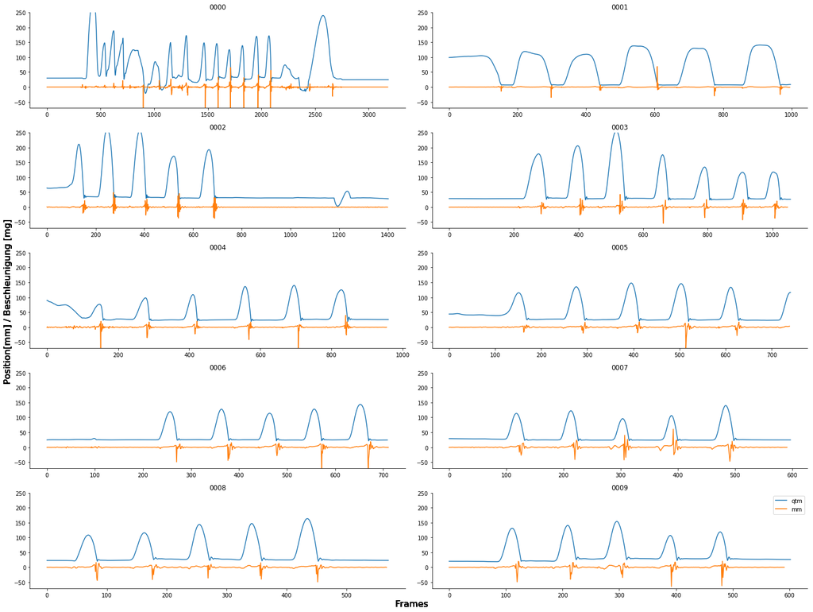

```python
fig = plt.figure(figsize=(20,15))

for i in range(10):
    mm = pd.read_csv(fIDs['mm'][i], delimiter=';', skiprows=4)
    qtm = pd.read_csv(fIDs['qtm'][i], delimiter='\t', skiprows=10)
    ax = fig.add_subplot(5,2,i+1)
    ax.plot(qtm.loc[:,'one Z'], label='qtm')
    ax.plot((mm.loc[:,'Becken Beschl. Sensor Z,mG'])/100, label='mm')
    ax.set_ylim(-70, 250)
    ax.set_title(re.search('000[0-9]', fIDs['qtm'][i]).group() )
    ax.spines['right'].set_visible(False)
    ax.spines['top'].set_visible(False)

    fig.text(0.5, 0.0001, 'Frames', ha='center', va='center', size=16)
    fig.text(0.0001, 0.5, 'Position[mm] / Beschleunigung [mg]', ha='center', va='center', rotation='vertical', size=16)

plt.legend()
plt.tight_layout()
plt.show()
```

### 3 Analyse der Events

1. Messungen *0000, 0001* werden aus der Analyse ausgeschlossen, da die Daten nicht vergleichbar zu den anderen Messungen sind. Die anderen 8 Messungen gehen in die Analyse ein.
2. Feststellung der Synchronisierung:

Die vorliegenden Testdaten basieren auf einem Setup mit einem QTM-Marker geklebt auf einem MM-Sensor, der hochgehoben wurde und relativ schnell auf den Boden gesetzt wurde. Demzufolge können wir annehmen, dass die z-Beschleunigung des Sensors an der ersten größeren Negativierung den Zeitpunkt *t_bodenMM* darstellt. Für den Marker können wir annehmen, dass das erste Erreichen des Minimums des z-Wertes den Zeitpunkt t_bodenQTM darstellt. t_delta = t_bodenMM - t_bodenQTM zeigt den Synchronisierungsunterschied an.

Für uns ist also nun interessant die beiden genannten Events (*z_min Pos QTM Maker, z_min Accel myoMOTION Sensor*) zu detektieren und den zeitlichen Unterschied der beiden pro Messung und pro Auftreten zu erfassen:

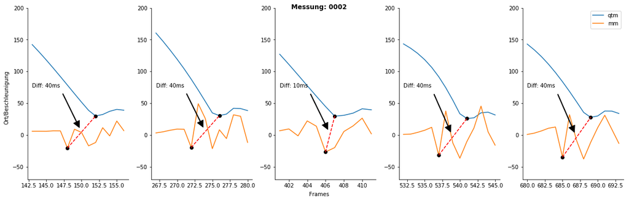

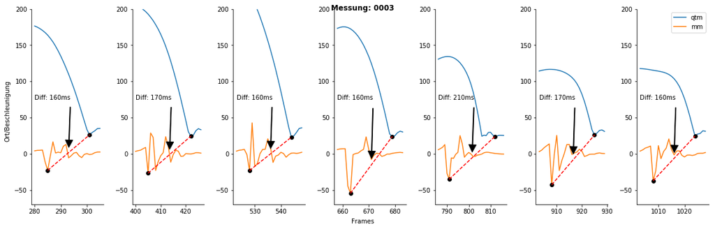

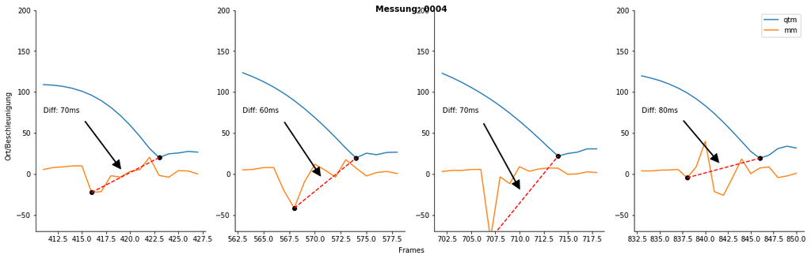

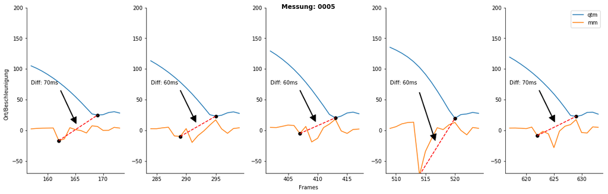

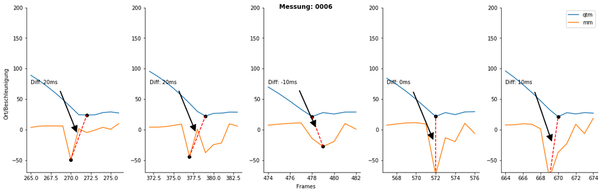

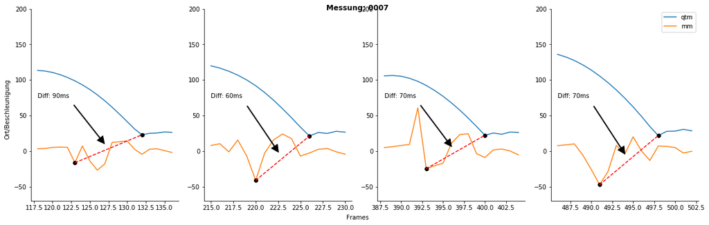

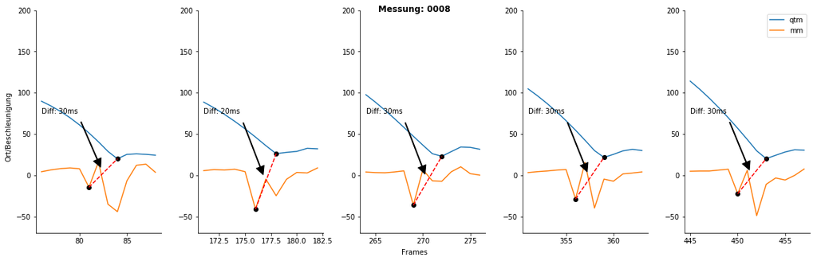

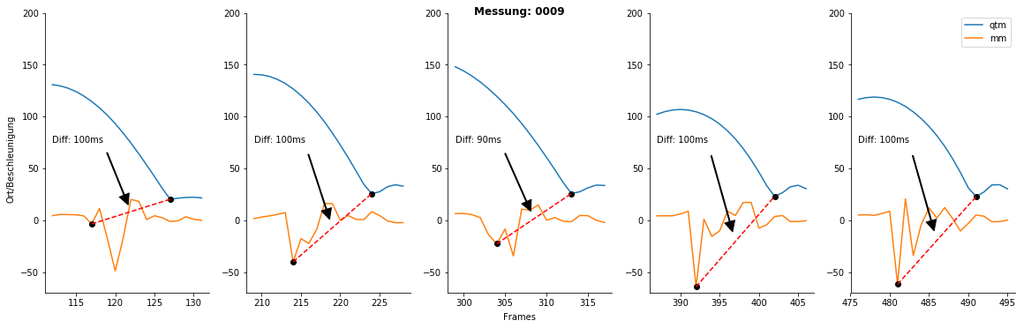

```python
from scipy.signal import find_peaks

def find_difference(qtm, mm):
    inverted = mm['Becken Beschl. Sensor Z,mG'] * -1
    peaks, _ = find_peaks(qtm['one Z'], height=100)
    index_qtm = []
    index_mm = []
    mini_qtm = []
    mini_mm = []
    for peak in peaks:
        index_qtm.append(qtm['one Z'].iloc[peak:peak+50].idxmin())
        mini_qtm.append(qtm['one Z'].iloc[peak:peak+50].min())
        index_mm.append(find_peaks(inverted.iloc[peak:peak+50], height=300)[0][0] + peak)
        peak_mm = find_peaks(inverted.iloc[peak:peak+50], height=300)
        mini_mm.append(peak_mm[1]['peak_heights'][0]*-1)

    delta_t = np.array(index_qtm) - np.array(index_mm)

    return delta_t, index_qtm, index_mm, mini_qtm, mini_mm


all_diffs, mean_diffs, std_diffs = [], [], []
for i in range(8):
    i += 2
    mm = pd.read_csv(fIDs['mm'][i], delimiter=';', skiprows=4)
    qtm = pd.read_csv(fIDs['qtm'][i], delimiter='\t', skiprows=10)
    diffs, qtm_minis, mm_minis, peaks_qtm, peaks_mm = find_difference(qtm,mm)
    all_diffs.append(diffs)
    std_diffs.append(np.std(diffs))
    mean_diffs.append(np.mean(diffs))

    # let's plot it
    fig = plt.figure(figsize=(16,5))
    k = 5 # make plotting window bigger
    div = 100
    for j, diff in enumerate(diffs):
        x1, x2 = mm_minis[j], qtm_minis[j]
        y1, y2 = peaks_mm[j]/div, peaks_qtm[j]
        mm_data = (mm['Becken Beschl. Sensor Z,mG'].iloc[mm_minis[j]-k:qtm_minis[j]+k])/div
        qtm_data = qtm['one Z'].iloc[mm_minis[j]-k:qtm_minis[j]+k]

        # plot data and peaks/minimas as dots
        ax = fig.add_subplot(1, len(diffs), j+1)
        ax.plot(qtm_data, label='qtm')
        ax.plot(mm_data, label='mm')
        ax.plot(x1, y1, 'o', c='black')
        ax.plot(x2, y2, 'o', c='black')

        # draw line and annotate delta_t
        ax.plot([x1, x2], [y1, y2], '--', c='red')
        ax.annotate('Diff: '+ str(diff*10) + 'ms', xy=((x1+x2)/2, (y1+y2)/2), xytext=(x1-k, 75),
                    arrowprops=dict(facecolor='black', shrink=0.1, width=1))

        # make nice
        ax.spines['right'].set_visible(False)
        ax.spines['top'].set_visible(False)
        ax.set_ylim(-70,200)

    plt.suptitle("Messung: " + re.search('000[0-9]', fIDs['qtm'][i]).group(), fontweight='bold')
    fig.text(0.5, 0.0001, 'Frames', ha='center', va='center')
    fig.text(0.0001, 0.5, 'Ort/Beschleunigung', ha='center', va='center', rotation='vertical')
    plt.legend()
    plt.tight_layout()
    plt.show()
```

```python
#print(mean_diffs)
#print(np.mean(mean_diffs))
#print(np.std(mean_diffs))
#print(std_diffs)
```

#### 4 Ergebnisse

Die Analyse der zeitlichen Unterschiede der beiden gemessenen Events ergeben folgendes Ergebnis:

| Messung | MW [ms] | SD [ms] |
| --- | --- | --- |
| 0002 | 34.00 | 12.00 |
| 0003 | 170.00 | 16.90 |
| 0004 | 70.00 | 7.07 |
| 0005 | 64.00 | 4.89 |
| 0006 | 8.00 | 11.66 |
| 0007 | 72.50 | 10.90 |
| 0008 | 28.00 | 4.00 |
| 0009 | 98.00 | 4.00 |

Der Mittelwert der zeitlichen Differenz zwischen QTM und myoMOTION über alle Messungen beträgt 68.06ms, die Standardabweichung hat einen Wert von 47.04ms.

#### 5 Dikussion

Die recht hohe Standardabweichung von 47.04ms über alle Trials deutet darauf hin, dass die Synchronität zwischen myoMOTION und QTM recht variable zu sein scheint; allerdings sind die Standardabweichungen innerhalb der Trials recht klein, d.h. unter der Annahme, dass der Algorithmus nicht alle Events korrekt identifiziert (zu sehen im Plot bei Messung 0003 für das Minimum des QTM Markers), können wir davon ausgehen, dass kein zeitlicher Drift innerhalb der Messungen auftritt, also alle Events bei beiden Systemen zum gleichen Zeitpunkt detektiert werden (innerhalb der Messung).

Zwischen den Messungen gibt es allerdings erhebliche Unterschiede, was in den Mittelwerten der zeitlichen Unterschiede deutlich wird, dir zwischen 170.00ms und 8.00ms starkt gestreut liegen. Die Ursache dessen müsste noch genauer untersucht werden, ggf. gibt es einen Zusammenhang zwischen den unterschiedlichen Längen der Messungen von myoMOTION.

#### 6 Zusammenfassung

Die zeitlichen Unterschiede sind bei vorliegendem Test geringer (MW: 68.06ms), als die von Ursula übermittelten (MW: 243ms), allerdings sind beide ermittelten Standardabweichungen recht ähnlich: SD_ursula = 42ms, sd_velamed = 47.04ms.

Außerdem können auch wir bestätigen, dass QTM später startet als MR3. Die 20ms Delay von Drücken des Triggerbuttons bis zum Start der Messung in QTM, könnten hier einen Hinweis liefern, da alle Messungen - außer Messung *0006* - einen Zeitversatz von > 20ms aufweisen.

Insgesamt müssen wir hier also nochmal weiter forschen bezüglich der Ursache des Phänomens. Es gibt allerdings zwei positive Nachrichten:

1. Es existiert kein zeitlicher Drift innerhalb der Trials, d.h. wenn der zeitliche Unterschied festgestellt werden kann, haben wir die Möglichkeit die Daten entsprechend zeitlich übereinander zu legen.
2. In QTM kann man den Trigger per BNC mit dem A/D-Board verbinden und entsprechend aufnehmen; in MR3 wird der eingehende Trigger automatisch aufgenommen, d.h. wir könnte hier exakt den zeitlichen Unterschied bestimmen, was künftige Messungen betrifft.

Zur genaueren Ursachenforschung müsste man Punkt 2 verwenden und ein entsprechendes Testsetup entwickeln, dass die Unterschiede erklärt. Ggf. könnte das ein Velamed'sches - Ludwighafen'sches Kooperationsprojekt sein.

```python
# mean_diffs = np.array(mean_diffs)
# sync_indeces1 = np.array(length[2][2:])
# sync_indeces1.shape
```

```python
# arr = np.vstack((mean_diffs, sync_indeces1))
# np.corrcoef(arr)
```